# Funtional Programming

Melissa

August 14, 2014

rm(list=ls()) library(pryr)

**Motivation**

```r
set.seed(1014)
df <- data.frame(replicate(6, sample(c(1:10, -99), 6, rep = TRUE)))
names(df) <- letters[1:6]
df
```

```
##    a  b c   d   e f
## 1  1  6 1   5 -99 1
## 2 10  4 4 -99   9 3
## 3  7  9 5   4   1 4
## 4  2  9 3   8   6 8
## 5  1 10 5   9   8 6
## 6  6  2 1   3   8 5
```

```r
fix_missing <- function(x) {
  x[x == -99] <- NA
  x
}
df[] <- lapply(df, fix_missing)
```

-lapply() is called a functional, because it takes a function as an argument -Another functional programming technique: storing functions in lists

```r
summary <- function(x) {
  funs <- c(mean, median, sd, mad, IQR)
  lapply(funs, function(f) f(x, na.rm = TRUE))
}

summary(df)
```

```
## Error: need numeric data
```

```r
summary <- function(x) {
 c(mean(x, na.rm = TRUE),
   median(x, na.rm = TRUE),
   sd(x, na.rm = TRUE),
   mad(x, na.rm = TRUE),
   IQR(x, na.rm = TRUE))
}
```

Question?- the summary above didnt apply the functions to all the columns right?

**Anonymous functions**

1. Given a function, like “mean”, match.fun() lets you find a function. Given a function, can you find its name? Why doesn’t that make sense in R?

No because functions in R are not immediately bound to a name. This is why you can have anonymous functions.

```r
match.fun(sd)
```

```
## function (x, na.rm = FALSE)
## sqrt(var(if (is.vector(x)) x else as.double(x), na.rm = na.rm))
## <bytecode: 0x7fc495b42a00>
## <environment: namespace:stats>
```

2. Use lapply() and an anonymous function to find the coefficient of variation (the standard deviation divided by the mean) for all columns in the mtcars dataset.

```r
lapply(mtcars, FUN=function(x) sd(x)/mean(x))
```

```
## $mpg
## [1] 0.3
##
## $cyl
## [1] 0.2886
##
## $disp
## [1] 0.5372
##
## $hp
## [1] 0.4674
##
## $drat
## [1] 0.1487
##
## $wt
## [1] 0.3041
##
## $qsec
## [1] 0.1001
##
## $vs
## [1] 1.152
##
## $am
## [1] 1.228
##
## $gear
## [1] 0.2001
##
## $carb
## [1] 0.5743
```

3. Use integrate() and an anonymous function to find the area under the curve for the following functions. Use Wolfram Alpha to check your answers.

y = x ^ 2 - x, x in [0, 10]

```r
integrate(f= function(x) x^2-x, lower=0, upper=10)
```

```
## 283.3 with absolute error < 3.1e-12
```

y = sin(x) + cos(x), x in [-π, π]

```r
integrate(f= function(x) sin(x) + cos(x), lower=-pi, upper=pi)
```

```
## 5.232e-16 with absolute error < 6.3e-14
```

y = exp(x) / x, x in [10, 20]

```r
integrate(f= function(x) exp(x)/x, lower=10, upper=20)
```

```
## 25613160 with absolute error < 2.8e-07
```

4. A good rule of thumb is that an anonymous function should fit on one line and shouldn’t need to use {}. Review your code. Where could you have used an anonymous function instead of a named function? Where should you have used a named function instead of an anonymous function?

**Closures**

-Closures get their name because they enclose the environment of the parent function and can access all its variables -unenclose() This function replaces variables defined in the enclosing environment with their values -Function factories are particularly well suited to maximum likelihood problems -Having variables at two levels allows you to maintain state across function invocations. This is possible because while the execution environment is refreshed every time, the enclosing environment is constant.

```r
i <- 0
new_counter2 <- function() {
  i <<- i + 1
  i
}

new_counter2()
```

```
## [1] 1
```

```r
new_counter2()
```

```
## [1] 2
```

Counter 2 does increase everytime the function is called because i is changed in the global environment using <<- However, new_counter has to be called for the counter to increase and it doesnt create another function.

```r
new_counter3 <- function() {
  i <- 0
  function() {
    i <- i + 1
    i
  }
}

counter_one<-new_counter3()
counter_one()
```

```
## [1] 1
```

```r
counter_one()
```

```
## [1] 1
```

In this case, in counter 3, a new function is created, however, since the counter is not modified in the closure but on the calling environment, it is restarted every time the function counter_one is called. Not using <<- means the counter is not modified in the parent environment.

1. Why are functions created by other functions called closures?

Because they enclose the environment of the parent environment, and they can use all of the parents objects.

2. What does the following statistical function do? What would be a better name for it? (The existing name is a bit of a hint.)

It creates two functions depending on the value of lambda. One where if lamba is zero, it creates a function that calculates the log of x, otherwise, it creates a function that calculates x to the power of lamba-1/lambda.

```r
bc <- function(lambda) {
  if (lambda == 0) {
    function(x) log(x)
  } else {
    function(x) (x ^ lambda - 1) / lambda
  }
}
```

3. What does approxfun() do? What does it return?

aproxfun() is a function that creates a function that interpolates between data points. It returns a function

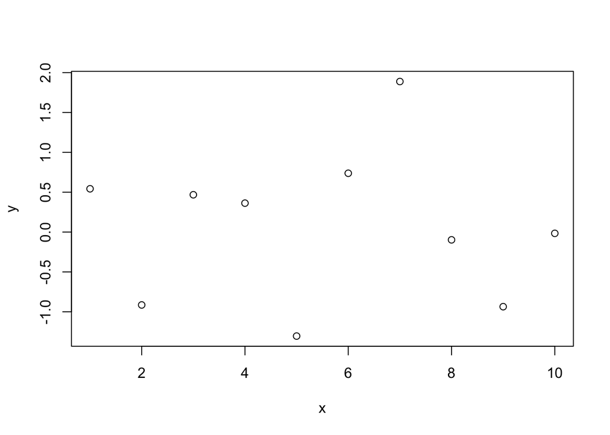

```r
x<-1:10
y<-rnorm(10)

plot(x,y)
```

```r
inter<-approxfun(x,y)
inter
```

```
## function (v)
## .approxfun(x, y, v, method, yleft, yright, f)
## <bytecode: 0x7fc495aabee0>
## <environment: 0x7fc495aac830>
```

```r
inter(5:10)
```

```
## [1] -1.30454  0.73778  1.88850 -0.09745 -0.93585 -0.01595
```

4. What does ecdf() do? What does it return?

ecdf creates a function that returns the percentiles for x

5. Create a function that creates functions that compute the ith central moment of a numeric vector. You can test it by running the following code:

```r
moment<-function(k){
  function(x){
    if(!is.numeric(x)){stop('x not numeric')}
    m<-(1/length(x))*((sum(x-mean(x)))^k)
    return(m)
  }
}
```

```r
m1 <- moment(1)
m2 <- moment(2)

x <- runif(100)
stopifnot(all.equal(m1(x), 0))
stopifnot(all.equal(m2(x), var(x) * 99 / 100))
```

```
## Error: all.equal(m2(x), var(x) * 99/100) is not TRUE
```

6. Create a function pick() that takes an index, i, as an argument and returns a function with an argument x that subsets x with i.

```r
pick<-function(i){
  function(x){
    x[[i]]
  }
}

lapply(mtcars, pick(5))
```

```
## $mpg
## [1] 18.7
##
## $cyl
## [1] 8
##
## $disp
## [1] 360
##
## $hp
## [1] 175
##
## $drat
## [1] 3.15
##
## $wt
## [1] 3.44
##
## $qsec
## [1] 17.02
##
## $vs
## [1] 0
##
## $am
## [1] 0
##
## $gear
## [1] 3
##
## $carb
## [1] 2
```

```r
# should do the same as this
lapply(mtcars, function(x) x[[5]])
```

```
## $mpg
## [1] 18.7
##
## $cyl
## [1] 8
##
## $disp
## [1] 360
##
## $hp
## [1] 175
##
## $drat
## [1] 3.15
##
## $wt
## [1] 3.44
##
## $qsec
## [1] 17.02
##
## $vs
## [1] 0
##
## $am
## [1] 0
##
## $gear
## [1] 3
##
## $carb
## [1] 2
```

**List of functions**

-easier to work with groups of related functions -to summarise an object in multiple ways

1. Implement a summary function that works like base::summary(), but uses a list of functions. Modify the function so it returns a closure, making it possible to use it as a function factory.

```r
summary(x)
```

```
## [1] 0.5113 0.5232 0.2815 0.3715 0.4791
```

```r
sum_Melissa<-list(
  Mel_min = function(x) min(x),
  Mel_1Qua = function(x) quantile(x,0.25),
  Mel_median = function(x) median(x),
  Mel_mean = function(x) mean(x),
  Mel_3Qua = function(x) quantile(x,0.75),
  Mel_max = function(x) max(x)
  )

lapply(sum_Melissa,function(f) f(x))
```

```
## $Mel_min
## [1] 0.01148
##
## $Mel_1Qua
##    25%
## 0.2593
##
## $Mel_median
## [1] 0.5232
##
## $Mel_mean
## [1] 0.5113
##
## $Mel_3Qua
##    75%
## 0.7384
##
## $Mel_max
## [1] 0.9971
```

```r
sum_Melissa_factory<-function(){
  list(
    Mel_min<- function(x) min(x),
  Mel_1Qua<- function(x) quantile(x,0.25),
  Mel_median<- function(x) median(x),
  Mel_mean<- function(x) mean(x),
  Mel_3Qua<- function(x) quantile(x,0.75),
  Mel_max<-function(x) max(x)
  )
}


m<-sum_Melissa_factory()
m[[2]](1:10)
```

```
##  25%
## 3.25
```

2. Which of the following commands is equivalent to with(x, f(z))?

```r
with(mtcars, mean(mpg))
```

```
## [1] 20.09
```

f(x$z) or f(z) if mtcars is attached before